# Production Information System

CHAPTER 3: Data Modeling

Dr. Jomana Bashatah

ISE Department - Year 4/ Level 7

2025-09-14

## Outline

1. Introduction
2. Entity-Relationship (E-R) Modeling
3. Normalization
4. Case Study in Data Modeling

## 1. Introduction

In 1975, a general architecture for data representation was developed by the Standards Planning and Requirements Committee (SPARC) of the American National Standards Institute (ANSI).

The ANSI/SPARC architecture is a three-level architecture based on three views of the data in the database:

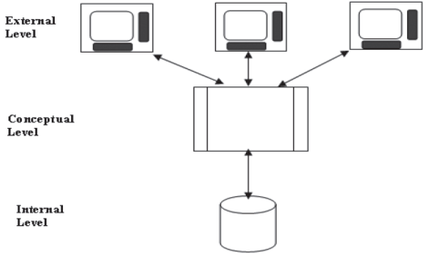

## 1. Introduction

- The **external level** Addresses the way in which different users view the database
- Includes those entities and attributes that the user sees and interacts with
- The actual implementation involves user interfaces that are used to interact with the database
- These interfaces are typically designed as “forms” and “reports”
- The user “view” can also include representations of the data that are not stored in the database

## 1. Introduction

- The **conceptual level** is a holistic view of the database at the level that defines entities, their attributes, and their relationships
- Describes **what** data are stored in the database, but **not how** they are stored
- The conceptual level is a logical description of the database without saying anything about its implementation
  - Therefore, it is independent of any specific hardware or software platforms
- The conceptual level is the foundation for the external level design

## 1. Introduction

- The **internal level** addresses the data structures and the file organization that are used to store data within the computer
- Whereas the conceptual level defines **what** data are stored, the internal level defines **how** data are stored
- This includes:
  - Data compression
  - Data encryption
  - Use of indexes
  - Hashing schemes
  - Other details
- The internal level is dependent on the operating system and physical components of the computer system

## 1. Introduction

In this chapter, we focus on the **conceptual, or logical, design** of the database:

- We refer to this as the design of a **data model**
- The data model provides a representation of:
  - The entities in the enterprise
  - The attributes of those entities
  - The relationships that exist among entities
- Several related modeling formalisms are used to develop relational data models
- We describe Chen’s entity-relationship (E-R) modeling technique as the foundation of principles for data modeling

## 2. Entity-Relationship (E-R) Modeling

The purpose of E-R modeling is to design a conceptual schema of entities and their relationships in order to:

1. **Facilitate the process of communication** among analysts, managers, and users of data
2. **Design a common data model** that will accommodate the different needs of individuals and organizations within the enterprise
3. **Establish a logical model** that can be implemented in a database management system (DBMS)

## 2. Entity-Relationship (E-R) Modeling

- The E-R model is a **conceptual model** and does not depend on any particular hardware or software
- E-R modeling is an **interactive process** that is carried on between the designer of the database application and the individuals in the organization that is the subject of the data model

## 2. Entity-Relationship (E-R) Modeling

### 2.1 E-R Modeling Primitives

The E-R modeling approach focuses on three aspects of data:

1. **Entity sets**
2. **Attributes**
3. **Relationships** between entity sets
- The E-R diagram uses a **box** to represent an entity set
- In the E-R modeling formalism:
  - The term “entity” describes what is referred to as “entity set”
  - The term “entity instance” describes what we refer to as an “entity” or “record”

## 2. Entity-Relationship (E-R) Modeling

### 2.1 E-R Modeling Primitives

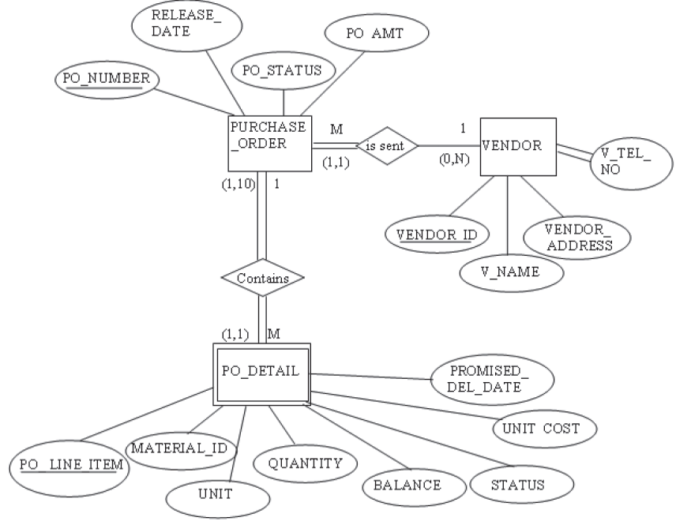

Entity Relationship (E-R) Diagram

## 2. Entity-Relationship (E-R) Modeling

### 2.1 E-R Modeling Primitives

- E-R diagrams distinguish between **weak** and **strong** entities
- An entity is **weak** if its existence is dependent on the existence of another entity
  - Shown in an E-R diagram by using a **double-sided rectangle**
  - Example: PO_DETAIL is dependent on the existence of PURCHASE_ORDER
  - Sometimes referred to as a **child** in a parent-child relationship
  - The primary key of the weak (child) entity is at least in part derived from the parent entity
- A **strong entity** is not existence dependent on some other entity
  - Represented by a **single-sided rectangle**

## 2. Entity-Relationship (E-R) Modeling

### 2.1 E-R Modeling Primitives

- In the E-R modeling formalism, **attributes** are represented by **ovals** with a line joining them to the entity
- **Primary keys** are indicated by underlining the attribute name
- Examples:
  - PO_NUMBER is the primary key attribute of PURCHASE_ORDER
  - VENDOR_ID is the primary key for VENDOR

## 2. Entity-Relationship (E-R) Modeling

### 2.1 E-R Modeling Primitives

- In E-R models, **Foreign keys are not shown**
  - VENDOR_ID is the foreign key that links PURCHASE_ORDER to the entity VENDOR
- When tables are implemented from an E-R model, a table must contain, as a foreign key, the primary key of any table to which it is related.
  - Foreign keys will be inherited when tables are created from the E-R model
  - Therefore, it is unnecessary to show the attribute VENDOR_ID with the entity PURCHASE_ORDER. VENDOR_ID will be inherited by PURCHASE_ORDER when the tables are created

## 2. Entity-Relationship (E-R) Modeling

### 2.1 E-R Modeling Primitives

- In the conceptual modeling stage, attributes are sometimes introduced without consideration as to how they would be implemented in the database tables
- An example of this is introducing **composite attributes** into the model
- A **composite attribute** is an attribute that can be further broken down into more specific attributes
- Example: VENDOR_ADDRESS can be subdivided into:
  - Street
  - City
  - State
  - Zip code

## 2. Entity-Relationship (E-R) Modeling

### 2.1 E-R Modeling Primitives

An attribute may be described as being either single valued or multivalued :

- A **single-valued Attribute** will have only one entry in each instance of that attribute
  - Example: PO_NUMBER - only one purchase order number per entry
- Other attributes may have more than one value (**multivalued**)
  - Example: Consider the attribute V_TEL_NO of the entity VENDOR. The vendor may have more than one primary telephone number that should be kept track of in the database.
  - At the early design stage, indicate with **double lines** connecting the attribute to the entity

## 2. Entity-Relationship (E-R) Modeling

### 2.1 E-R Modeling Primitives

The **relationship** is a description of the association between entities.

Relationships have three components:

1. **Connecting arcs**
- connect entities that are related to each other
- VENDOR is related to PURCHASE_ORDER and PURCHASE_ORDER is related to PO_DETAIL
2. **Diamonds**
- contain verb or verb phrase expressing the general relationship
- VENDOR is sent PURCHASE_ORDER”
- “PURCHASE_ORDER contains PO_DETAIL”
3. **Cardinality**
- expresses the number of entity occurrences associated with one occurrence of the related entity.
- Cardinality is indicated by numbers or symbols written at the ends of the relationship arc
- Three common cardinalities on E-R diagrams:
  - **One-to-many (1:M)**
  - **One-to-one (1:1)**
  - **Many-to-many (M:N)**

## 2. Entity-Relationship (E-R) Modeling

### 2.1 E-R Modeling Primitives

The cardinality 0 : M means that each instance of one entity is associated with zero, one, or many instances of the entity on the M side of the relationship

Examples:  
- “One vendor is sent 0, 1 or many purchase orders” (0:M)  
- “One purchase order contains 1 or many purchase order details” (1:M)

## 2. Entity-Relationship (E-R) Modeling

### 2.1 E-R Modeling Primitives

A **one-to-one relationship** often indicates that the two entities involved can be combined into a single entity.

**Why?**

A record in one table will be related to one and only one record in another table to which it has a one-to-one relationship. Therefore, no increase in the number of rows will occur if both entities are combined in one table.

## 2. Entity-Relationship (E-R) Modeling

### 2.1 E-R Modeling Primitives

- A useful graphical tool that assists in **visualizing the cardinality** of a relationship is called a **semantic net diagram**
- Examples of the instances of two entities are connected by relationship lines

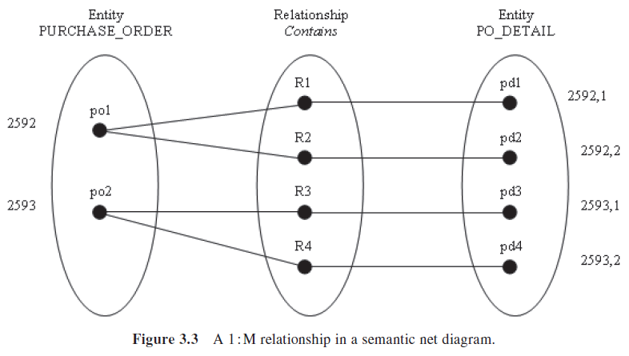

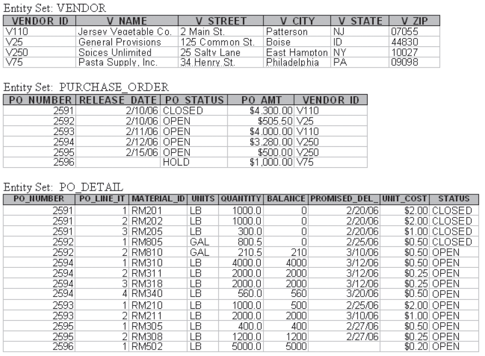

## 2. Entity-Relationship (E-R) Modeling

### 2.1 E-R Modeling Primitives

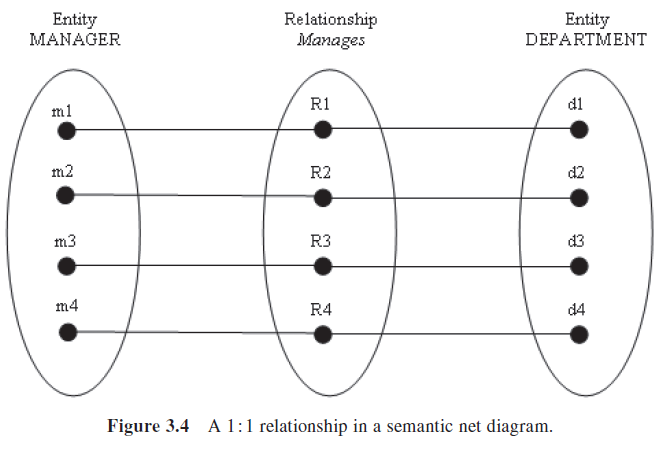

## 2. Entity-Relationship (E-R) Modeling

### 2.1 E-R Modeling Primitives

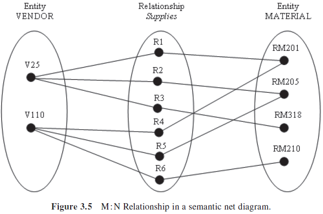

## 2. Entity-Relationship (E-R) Modeling

### 2.1 E-R Modeling Primitives

- It is often desirable to add **cardinality limits** to the E-R diagram to be more specific about the domain of the cardinality relationship
  - Cardinality limits are shown in E-R diagram (S.11) as numbers in parentheses

Examples:  
- In the relationship between PURCHASE_ORDER and PO_DETAIL, the cardinality limits for PO_DETAIL are (1,1), which means that each PO_DETAIL will be associated with one purchase order  
- The cardinality limits on PURCHASE_ORDER is (1,10), which means that there will be a minimum of 1 and a maximum of 10 line items associated with one purchase order

- Cardinality limits are imposed based on the way in which the business is operated. Therefore, they are said to reflect the **business rules** of the enterprise.

## 2. Entity-Relationship (E-R) Modeling

### 2.1 E-R Modeling Primitives

Business rules affect the degree of an entity’s participation in a relationship.

There are two categories of entity participation:

1. **Optional (Partial) Participation**
   - One entity’s occurrence does not require the participation of the other entity
   - Shown by placing a **single line** arc near the optional entity
2. **Mandatory Participation**
   - Entity requires participation of the other entity in the relationship
   - Shown by placing a **double-lined** arc next to the mandatory entity

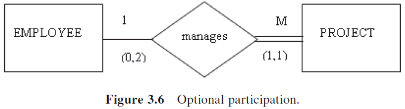

a PROJECT requires the participation of an EMPLOYEE, who manages it. Therefore, a double-lined arc is placed next to PROJECT to indicate that the participation is mandatory in the relationship

## 2. Entity-Relationship (E-R) Modeling

### 2.1 E-R Modeling Primitives

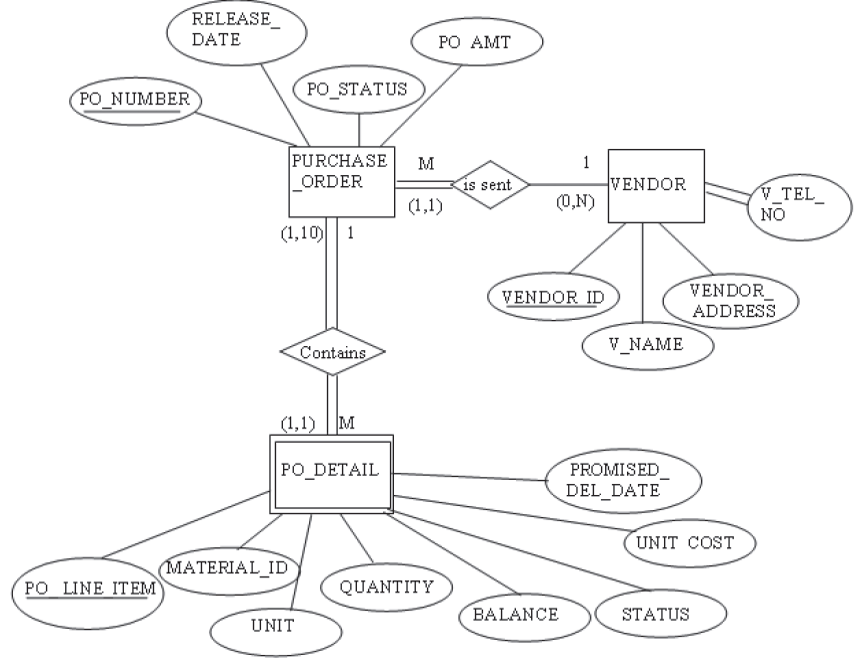

## 2. Entity-Relationship (E-R) Modeling

### 2.2 The Degree of a Relationship

The **degree of a relationship** is a measure of the number of entities sharing the same association.

Four cases:  
1. **Binary relationships** most common  
2. **Ternary relationships**  
3. **N-ary relationships**  
4. **Unary relationships**

## 2. Entity-Relationship (E-R) Modeling

### 2.2 The Degree of a Relationship

- The **binary** relationship is most common
- Exists when **two entities** have an associated relationship

Examples:  
- VENDOR and PURCHASE_ORDER share a binary relationship  
- PURCHASE_ORDER and PO_DETAIL share a binary relationship

## 2. Entity-Relationship (E-R) Modeling

### 2.2 The Degree of a Relationship

- The **ternary** relationship exists when three entities share a common relationship

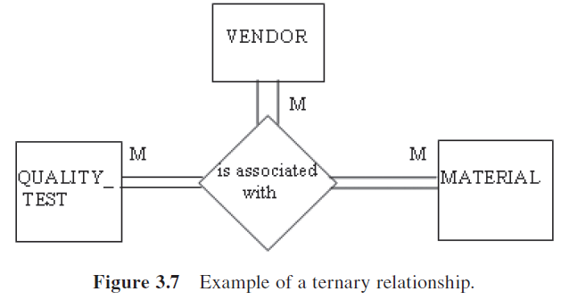

- Example: VENDOR, QUALITY_TEST, and MATERIAL entities associated with quality control testing

## 2. Entity-Relationship (E-R) Modeling

### 2.2 The Degree of a Relationship

- The **n-ary** relationship exists When more than three entities share a relationship
- The **unary** relationship exists when an association is maintained within a single entity (i.e., the entity has a relationship with itself)

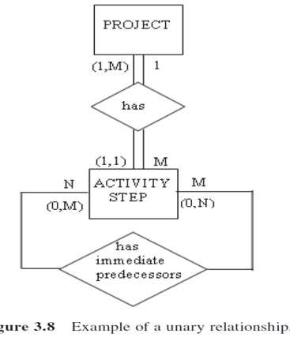

This is reflected in the unary relationship of ACTIVITY_STEP with itself, which is also called a **recursive relationship**

## 2. Entity-Relationship (E-R) Modeling

### 2.3 Recursive Entities

- **Recursive entities** are entities with unary relationships
- Naturally occurring in some important manufacturing problems
- **Typical example**: Product bill of materials (BOM), where parts are made of other parts

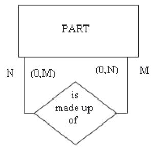

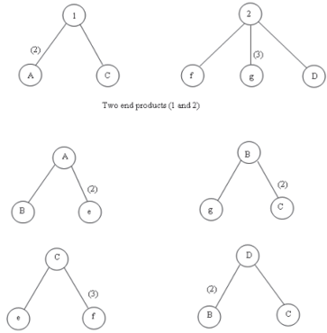

Example: PART entity with “is made up of” relationship to itself, showing how complex parts are composed of simpler parts.

## 2. Entity-Relationship (E-R) Modeling

### 2.4 Composite Entities

- The relational model requires the use of **1:M relationships**
- This enables queries to be designed that use the foreign key of the table on the M side of the relationship to retrieve corresponding unique rows on the 1 side of the relationship
- When **M:N relationships** are encountered in E-R diagram development, the analyst can break them down into a series of **1:M relationships** using a **composite entity**

## 2. Entity-Relationship (E-R) Modeling

### 2.4 Composite Entities

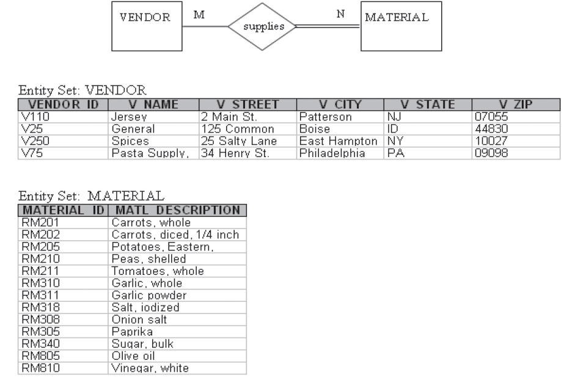

**Original M:N relationship**: VENDOR supplies MATERIAL  
- Many vendors can supply the same material  
- One vendor can supply many materials  
- Creates a many-to-many relationship that needs to be resolved

## 2. Entity-Relationship (E-R) Modeling

### 2.4 Composite Entities

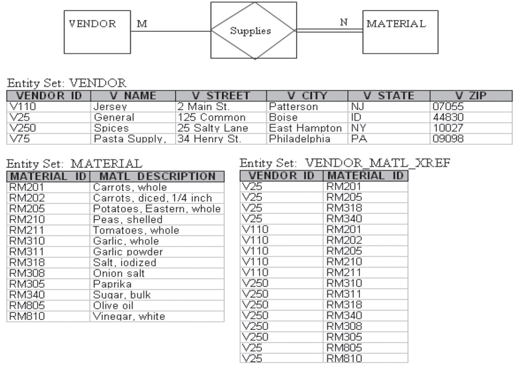

## 2. Entity-Relationship (E-R) Modeling

### 2.5 Superclass and Subclass Entity Types

To simplify the data model while maintaining useful information:

- Aggregate people, places, and things into as few entities as possible
- Consistent with the semantic requirements of the problem

Example: Raw materials, subassemblies, final assemblies, office materials, repair and maintenance materials could all be part of an entity called **MATERIAL**  
All instances of the MATERIAL entity have in common a material number, a description, a unit of measure (gallons, pounds), and so on

- There are attributes of MATERIAL that are unique to subgroups

## 2. Entity-Relationship (E-R) Modeling

### 2.5 Superclass and Subclass Entity Types

- A **Superclass** is an entity type that represents a set of similar people, places, or things
  - Have **common attributes** but represent **distinct subclasses**
- A **Subclass** is an entity that is a **member of a superclass**
  - Has **distinct attributes** that are not in common with all other members of the superclass

## 2. Entity-Relationship (E-R) Modeling

### 2.5 Superclass and Subclass Entity Types

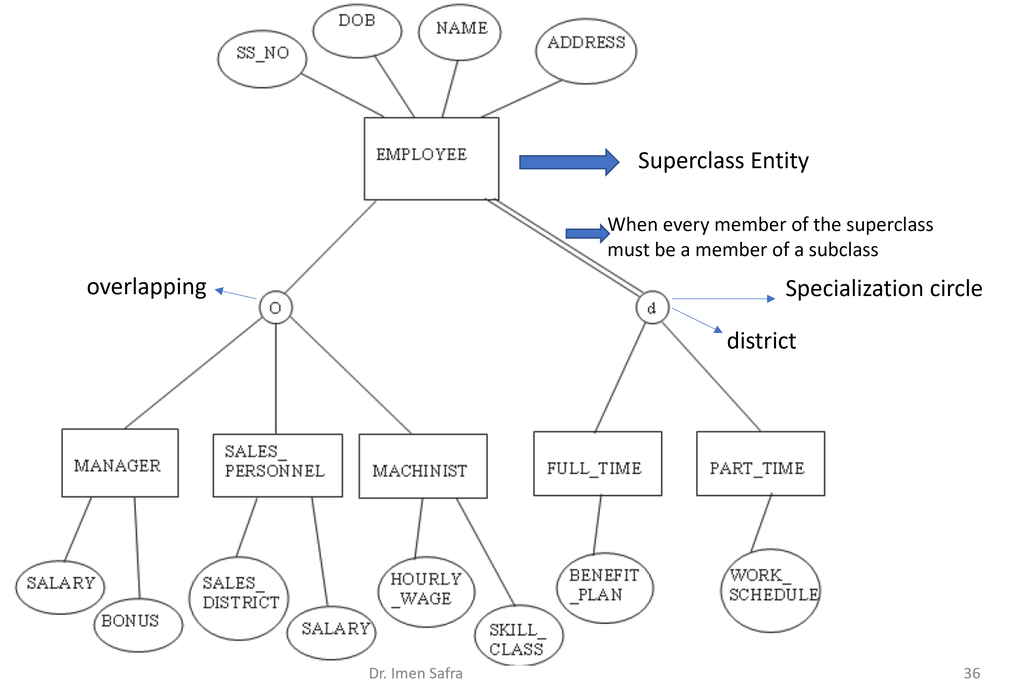

Key elements:

- **Superclass Entity** - main entity (e.g., EMPLOYEE)
- **Specialization circle** - connects superclass to subclasses
- **Disjoint (d)** - when every member of superclass must be in exactly one subclass
- **Overlapping (o)** - when members can belong to multiple subclasses

Example: EMPLOYEE superclass with MANAGER, SALES_PERSONNEL, MACHINIST subclasses and FULL_TIME, PART_TIME subclasses